# ISBN: 978-958-5153-36-3-G11-2024-1 Pregunta 39

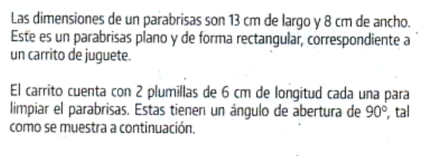

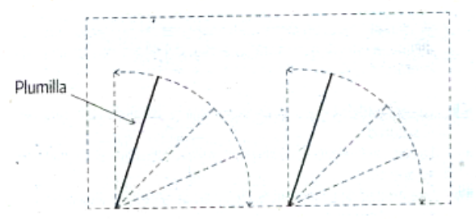

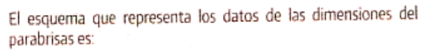

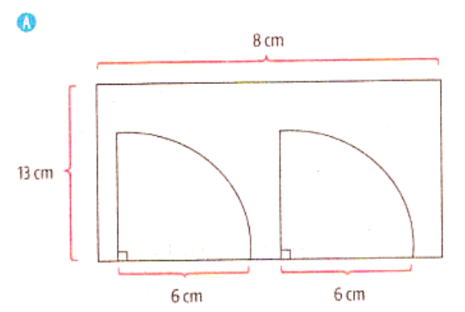

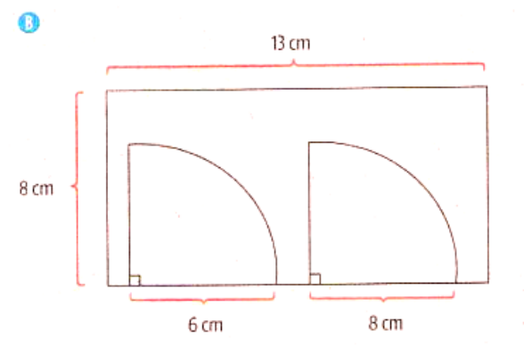

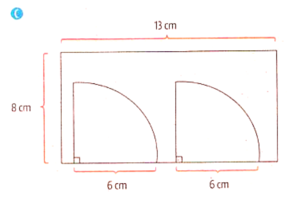

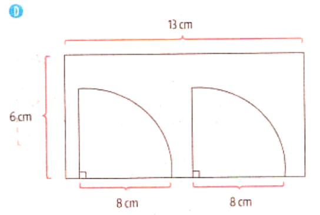

## Análisis del Problema

El problema nos presenta un escenario donde un carrito de juguete rectangular tiene un parabrisas con dos plumillas. Se nos dan las dimensiones del parabrisas (13 cm de largo y 8 cm de ancho) y la longitud de cada plumilla (6 cm). Se nos pide identificar el esquema que representa correctamente estas dimensiones.

## Análisis de las Opciones

Analicemos cada opción para determinar cuál representa correctamente las dimensiones del parabrisas y las plumillas:

**Opción A:**

**Conclusión:** La opción A es incorrecta debido a las dimensiones del parabrisas.

**Opción B:**

- **Dimensiones:** El esquema muestra un rectángulo con 13 cm de largo y 8 cm de ancho, lo que coincide con las dimensiones del parabrisas.
- **Plumillas:** Las plumillas se extienden desde el lado de 13 cm, lo cual es correcto. Sin embargo, una plumilla cubre un segmento de 6 cm mientras que la otra cubre un segmento de 8 cm. Esto contradice la información dada de que ambas plumillas tienen 6 cm de longitud.

**Conclusión:** La opción B es incorrecta debido a la longitud desigual de las plumillas.

**Opción C:**

- **Dimensiones:** El esquema muestra un rectángulo con 13 cm de largo y 8 cm de ancho, lo que coincide con las dimensiones del parabrisas.
- **Plumillas:** Ambas plumillas se extienden desde el lado de 13 cm y cada una cubre un segmento de 6 cm, coincidiendo con la información proporcionada.

**Conclusión:** La opción C parece ser la correcta hasta el momento.

**Opción D:**

- **Dimensiones:** El rectángulo tiene 13 cm de largo, pero muestra 6 cm de ancho, lo cual no coincide con el ancho del parabrisas que es de 8 cm.
- **Plumillas:** Las plumillas se extienden desde el lado de 13 cm, lo cual es correcto. Sin embargo, ambas plumillas cubren segmentos de 8 cm, lo que contradice la información dada de que cada plumilla tiene 6 cm de longitud.

**Conclusión:** La opción D es incorrecta debido a las dimensiones incorrectas del parabrisas y la longitud incorrecta de las plumillas.

## Retroalimentación Saber ICFES

# Pregunta y Análisis

Las dimensiones de un parabrisas son 13 cm de largo y 8 cm de ancho, con plumillas de 6 cm de longitud que forman un ángulo de 90°. Se evalúan cuatro esquemas para determinar cuál representa correctamente las dimensiones y la funcionalidad de las plumillas sobre el parabrisas.

## Opciones Analizadas

- **Opción A**: Plumillas paralelas al lado de 8 cm.
- **Opción B**: Plumillas paralelas al lado de 13 cm.
- **Opción C**: Correcta, plumillas paralelas al lado de 13 cm.
- **Opción D**: Plumillas paralelas al lado de 13 cm, pero inadecuadamente divididas.

## Retroalimentación

- **Nivel de Desempeño**: Nivel 2
- **Competencia**: Interpretación y representación
- **Aprendizaje y Evidencias**:
  - Comprende y transforma la información cuantitativa y esquemática presentada en diferentes formatos.
  - Da cuenta de las características básicas de la información presentada.
- **Componente**: Espacial-métrico
- **Tipo de pensamiento**: Espacial-métrico
- **Estándar Asociado**: Visualización y representación en el plano y el espacio
- **Categoría**: Geometría
- **Contenido Genérico**: Relaciones de paralelismo y ortogonalidad entre rectas
- **Situaciones o contexto**: Situaciones cotidianas simplificadas
- **Eje Axial Disciplinar**: Sólidos Desplegados y Plegados
- **¿Qué evalúa?**: La habilidad para identificar la orientación correcta de las plumillas en un parabrisas basado en sus dimensiones
- **Respuesta correcta**: Opción C
- **Justificación de la respuesta correcta**: Las plumillas están orientadas de manera que cubren el lado más largo del parabrisas, optimizando el área de limpieza.
- **Motivos que llevan a escoger cada una de las opciones incorrectas**:
  - **Opción A**: Incorrecta por orientación y cobertura ineficiente.
  - **Opción B y D**: Incorrectas debido a la presentación no óptima en el esquema del parabrisas.
- **Grados de aplicabilidad**: Dado el nivel de detalle y la necesidad de comprender el funcionamiento práctico de las plumillas en relación con las dimensiones del parabrisas, la pregunta podría ser más adecuada y desafiante para estudiantes de Secundaria, específicamente en grados 7° a 9°.